# 3.1 数据采集

在本实验中，我们使用了7个反编译得到的文本文件，分别来自不同的app：

- 新疆应用.txt
- Disco Lights.txt
- Minecraft Horror Mods for MCPE.txt
- ps.txt
- Urdu Text Poetry.txt
- Whats Web.txt
- 东家.txt

```python
import re
filepaths = [
    '新疆应用.txt',
    'Disco Lights.txt',
    'Minecraft Horror Mods for MCPE.txt',
    'ps.txt',
    'Urdu Text Poetry.txt',
    'Whats Web.txt',
    '东家.txt'
]
```

```python
def extract_urls(filepaths):
    urls = []
    for filepath in filepaths:
        with open(filepath, 'r', encoding='utf-8') as f:
            content = f.read()
            urls += re.findall(r'https?://[^\s\'"<>]+', content)
        return list(set(urls))

url_list = extract_urls(filepaths)
print(f"共提取URL数量: {len(url_list)}")
```

```
共提取URL数量: 61
```

将提取的URL分为https和http两类，便于下一步进行分析占比。

```python
https_raw = [u for u in url_list if u.lower().startswith('https://')]
http_raw = [u for u in url_list if u.lower().startswith('http://')]
print(f"原始数据中HTTPS数量：{len(https_raw)}")
print(f"原始数据中HTTP数量：{len(http_raw)}")
```

```
原始数据中HTTPS数量：43
原始数据中HTTP数量：18
```

# 3.2 数据清洗与预处理

```python
import pandas as pd
from urllib.parse import urlparse
```

```python
def clean_and_parse_urls(url_list):
    cleaned_urls = []
    for url in url_list:
        url = url.strip().lower()
        if url.startswith("http://") or url.startswith("https://"):
            cleaned_urls.append(url)
            url = url.split('?')[0]
    return cleaned_urls
```

对提取的list使用清洗函数，并创建DataFrame。提取出URL中的scheme和domain部分，并且检查URL中是否包含敏感词。

```python
cleaned_list = clean_and_parse_urls(url_list)
df_urls = pd.DataFrame(cleaned_list, columns=['url'])

df_urls['scheme'] = df_urls['url'].apply(lambda x: urlparse(x).scheme)
df_urls['domain'] = df_urls['url'].apply(lambda x: urlparse(x).netloc)

sensitive_keywords = ['login', 'password', 'token']
df_urls['is_sensitive'] = df_urls['url'].apply(lambda x: any(k in x for k in sensitive_keywords))

df_urls.head()
```

|  | url | scheme | domain | is_sensitive |
| --- | --- | --- | --- | --- |
| 0 | https://ok.ru/videoembed/1374373415456?autoplay=1 | https | ok.ru | False |
| 1 | https://mobile.events.data.microsoft.com/oneco... | https | mobile.events.data.microsoft.com | False |
| 2 | https://ok.ru/videoembed/1374372891168?autoplay=1 | https | ok.ru | False |
| 3 | https://ok.ru/videoembed/1374374857248?autoplay=1 | https | ok.ru | False |
| 4 | https://ok.ru/videoembed/1374374070816?autoplay=1 | https | ok.ru | False |

# 3.3 数据分析与挖掘

## 3.3.1 统计URL集合

我们通过统计每个URL的domain出现频率，分析哪些外部系统被频繁访问。同时统计http和https占比，来评估通信安全性。

```python
domain_counts = df_urls['domain'].value_counts()
print("Top 10 最常访问域名：")
print(domain_counts.head(10))

scheme_counts = df_urls['scheme'].value_counts()
print("\n协议类型占比：")
print(scheme_counts)
```

```
Top 10 最常访问域名：
ok.ru                               31
www.slf4j.org                        8
www.w3.org                           6
github.com                           2
kawa.gnu.org                         2
t.me                                 2
mobile.events.data.microsoft.com     1
www.gnu.org                          1
m.me                                 1
wa.me                                1
Name: domain, dtype: int64

协议类型占比：
https    43
http     18
Name: scheme, dtype: int64
```

#### 下面我们用饼图来展示http和https的占比

```python
import matplotlib.pyplot as plt
import seaborn as sns
```

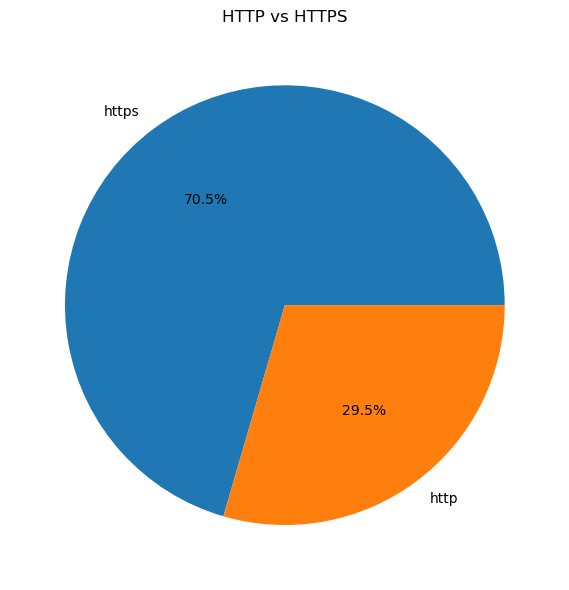

```python
plt.figure(figsize=(6, 6))
plt.pie(
    scheme_counts.values,
    labels=scheme_counts.index,
    autopct='%1.1f%%'
)
plt.title('HTTP vs HTTPS')
plt.tight_layout()
plt.show()
```

该图展示了URL中http和https的分布占比情况。 其中**https** 表示数据通过安全层进行传输，**http** 表示数据在网络中裸露传输，存在被拦截或篡改的风险。 通过统计‘urlparse’提取的‘scheme’字段，我们可以发现，https占比约为70.5%，http占比约为29.5%，这反映出大部分网络请求使用了加密协议，但仍然存在部分非加密传输，可能存在安全隐患。

#### 用柱状图展示top10域名访问频率

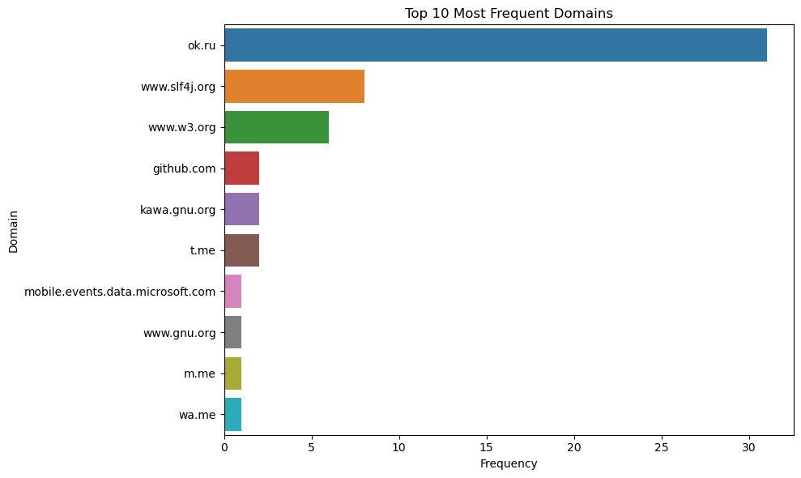

```python
plt.figure(figsize=(10, 6))
sns.barplot(
    x=domain_counts.head(10).values,
    y=domain_counts.head(10).index
)
plt.title('Top 10 Most Frequent Domains')
plt.xlabel('Frequency')
plt.ylabel('Domain')
plt.tight_layout()
plt.show()
```

## 3.3.2 模式分析

为了检查 URL 之间是否存在访问上的“强关联”，我们将每个 App 所访问的域名集合视为一个 transaction，并应用三种经典指标：

**支持度（Support）**  
Support(A → B) = 同时包含 A 和 B 的事务数 / 总事务数

**置信度（Confidence）**  
Confidence(A → B) = 同时包含 A 和 B 的事务数 / 包含 A 的事务数

**提升度（Lift）**  
Lift(A → B) = Confidence(A → B) / Support(B)

其中：

- A 是前项（antecedent）
- B 是后项（consequent）

安装'mlxtend'库，方便计算三项关联指标和使用Apriori算法

```python
pip install mlxtend
```

```python
from mlxtend.preprocessing import TransactionEncoder
from mlxtend.frequent_patterns import apriori, association_rules
```

提取每个app的域名集合作为事务

```python
transactions = []

for filepath in filepaths:
    with open(filepath, 'r', encoding='utf-8') as f:
        content = f.read()
        urls = re.findall(r'https?://[^\s\'"<>]+', content)
        domains = list(set([urlparse(u).netloc.lower() for u in urls]))
        transactions.append(domains)
```

转换为布尔矩阵

```python
te = TransactionEncoder()
df_matrix = pd.DataFrame(te.fit_transform(transactions), columns = te.columns_)
print(df_matrix.shape)
print(df_matrix.sum().sort_values(ascending=False).head(10))
```

```
(7, 201)
www.w3.org               6
play.google.com          5
github.com               4
schemas.microsoft.com    3
d.applvn.com             3
ms.applvn.com            3
ns.adobe.com             3
vid.applovin.com         3
assets.applovin.com      3
d.applovin.com           3
dtype: int64
```

#### 用Apriori算法计算频繁项集和计算三指标（支持度，置信度，提升度）

```python
frequent_itemsets = apriori(df_matrix, min_support=0.3, use_colnames=True, max_len=2)
rules = association_rules(frequent_itemsets, metric='lift', min_threshold=0.5)
rules[['antecedents', 'consequents', 'support','confidence','lift']].sort_values(by = 'lift', ascending = False)
```

|  | antecedents | consequents | support | confidence | lift |
| --- | --- | --- | --- | --- | --- |
| 0 | (a.applvn.com) | (a.applovin.com) | 0.428571 | 1.000000 | 2.333333 |
| 363 | (developer.apple.com) | (developer.android.com) | 0.428571 | 1.000000 | 2.333333 |
| 379 | (rt.applovin.com) | (developer.android.com) | 0.428571 | 1.000000 | 2.333333 |
| 378 | (developer.android.com) | (rt.applovin.com) | 0.428571 | 1.000000 | 2.333333 |
| 377 | (prod-a.applovin.com,https:) | (developer.android.com) | 0.428571 | 1.000000 | 2.333333 |
| ... | ... | ... | ... | ... | ... |
| 358 | (dash.applovin.com) | (www.w3.org) | 0.428571 | 1.000000 | 1.166667 |
| 544 | (play.google.com) | (www.w3.org) | 0.571429 | 0.800000 | 0.933333 |
| 545 | (www.w3.org) | (play.google.com) | 0.571429 | 0.666667 | 0.933333 |
| 447 | (www.w3.org) | (github.com) | 0.428571 | 0.500000 | 0.875000 |
| 446 | (github.com) | (www.w3.org) | 0.428571 | 0.750000 | 0.875000 |

604 rows × 5 columns

#### 我们对app中的URL访问域名集合构建关联规则模型，提取出了支持度，置信度和提升度的关联对，下面我们对结果进行分析。

通过这些分析，我们能看出App中不同URL之间的一些共现模式，有的关系很强（lift大于1），有的关系比较弱（lift小于1）。

#### 对于时间序列分析

因为.txt文件不包含每一个URL的“访问时间”信息，所以无法进行时间序列分析。 如果有动态源码，可以知道每个URL在什么时间被访问，访问了几次和访问是否重复，就可以构造出标准的时间序列X_t = hits at time t

# 3.4 可视化展示

```python
import matplotlib.pyplot as plt
```

[figure not shown]

```python
def clean_fset(fset):
    return ', '.join([u.split('.')[0] for u in list(fset)])

rules_sorted = rules.sort_values(by='lift', ascending=False).copy()
rules_sorted['rule'] = rules_sorted['antecedents'].apply(clean_fset) + " → " + rules_sorted['consequents'].apply(clean_fset)
rules_filtered = rules_sorted[rules_sorted['lift'] > 0].copy()

plt.figure(figsize=(14, 25))
plt.barh(rules_filtered['rule'], rules_filtered['lift'], color='skyblue')
plt.xlabel("Lift")
plt.title("Lift > 0 Picture")
plt.gca().invert_yaxis()
plt.yticks(fontsize=6)
plt.tight_layout()
plt.show()
```

可基于这些可视化图表构建交互式报告或者Dashboard实现。